# Vibe coding - lab

Computer-Aided Medical Diagnostics (MPA-PRM) - a computer lab with a coding agent, independent work

**ImportantStart here: the presentation**

[**Open the presentation: Vibe coding — an agent in the terminal →**](https://tomasvicar.github.io/AUI-public/lectures/vibe-coding.html)

We go through it **at the start of the lab**. It introduces the practical workflow you will use in the tasks below.

**Listen and revisit:** [Podcast in Czech and English — week 6](https://tomasvicar.github.io/AUI-public/podcasts/week-6.html). The podcast covers the introduction and the lab; it replaces neither the class nor your own practical work. For commentary while viewing the slides, open the [English narrated presentation](https://tomasvicar.github.io/AUI-public/lectures/vibe-coding-narrated-en.html) or the [Czech narrated presentation](https://tomasvicar.github.io/AUI-public/lectures/vibe-coding-narrated-cs.html).

**Independent work** at your own pace; what you do not finish in class you finish at home. Everything you need is on this page.  
**Bring:** a laptop (Windows, macOS or Linux), a [GitHub account](https://github.com/signup) and a **MetaCentrum account** for the free CERIT-SC models - apply **a week ahead**, approval takes days (part 1, step 1).

Compulsory hand-in: push **two tasks of your choice** (part 3) and **the big task** (part 5) to your private repository `aui-vibe-coding` shared with `MLRteacher` by **Friday 30 October 2026, 23:59**. What is pushed before the deadline counts. Hand-ins are checked with AI and for plagiarism. Attendance is not credited without it.

## What this lab is about

You install a coding agent in the terminal - a language model that **acts**: it reads your files, writes code, runs it, reads the error and fixes it. Then you do **two small tasks of your choice** out of seven and **one big task**: a convolutional network on blood-cell images, tuned by an Optuna study.

**Tools multiply what the model can do.** With access to a terminal, code execution and other tools, it can turn a request into a working result: create files, run an analysis, open a browser, inspect the output and fix a failure. It can repeat this loop using real feedback from the computer. That is why this lab uses an **AI agent**.

The agent writes the code. **You decide what you want, check what comes back, and stay responsible for it.**

### Four separate choices: model, provider, harness, computer

| Layer | Question | This lab |
| --- | --- | --- |
| **Model** | Who thinks? | Qwen behind CERIT-SC’s `agentic` alias |
| **Provider** | Who hosts the model? | CERIT-SC (e-INFRA CZ) |
| **Harness** | Which program reads files and uses tools? | Claude Code |
| **Computer** | Where do the commands run? | your laptop |

These are separate choices. **Claude Code does not imply a Claude model**, and a remote model does not move your training code onto the provider’s GPU. The provider’s **endpoint** is its address; your API key identifies your account. Aliases can change their underlying model.

Some supported combinations:

| Model | Provider | Harness | Commands run on |
| --- | --- | --- | --- |
| Qwen via `agentic` | CERIT-SC | Claude Code | your laptop |
| Claude | Anthropic | Claude Code | your laptop |
| supported OpenAI model | OpenAI | Codex CLI | your laptop |
| supported open-weight model | Ollama, local | Codex CLI, local mode | your laptop |
| Qwen via `agentic` | CERIT-SC | Claude Code over SSH | university server |

For the last row, start the harness **on the server**; it still calls the remote model. Alternatively, a harness on your laptop can send selected commands over SSH. Model/provider compatibility, authentication and tool support must match; these rows are examples, not arbitrary interchangeable parts. [Codex local-provider mode](https://learn.chatgpt.com/docs/cli/reference) uses a compatible model already installed in Ollama.

### Which agent

This page walks through **Claude Code with free CERIT-SC models**. You can use your own agent and account instead; the hand-in is the same.

- **ChatGPT** → [Codex](https://developers.openai.com/codex/cli);
- **Claude** → Claude Code as below, skip step 3 and sign in with your account;
- **Gemini** → [Antigravity](https://antigravity.google/);
- **GitHub Copilot Student** → [Copilot CLI](https://docs.github.com/en/copilot/get-started/cli-quickstart).

**NoteChoose your agent: CERIT-SC, Antigravity, Codex or Copilot Student**

**CERIT-SC + Claude Code** is the worked example below. Apply for a [MetaCentrum account](https://metavo.metacentrum.cz/en/application/index.html) **a week ahead** (part 1, step 1). The other routes have limited free access; availability depends on your account and current plan. They use the same tasks and hand-in, but you sign in to their own services instead of setting a CERIT-SC API key.

**Antigravity (Google).** A free plan includes a limited weekly agent quota; [paid plans raise it](https://www.antigravity.google/docs/plans). Install the CLI in PowerShell with `irm https://antigravity.google/cli/install.ps1 | iex`, or on macOS/Linux with `curl -fsSL https://antigravity.google/cli/install.sh | bash`. Open a new terminal, run `agy --version`, then `agy` and sign in. In your project folder, launch automatic tool approval with `agy --dangerously-skip-permissions`. Check remaining quota with `/usage` (also `/quota`) inside the agent. If you have eligible personal and school Google accounts, you may choose one; school access can require institutional setup and the quota depends on that account. Switch with `/logout`, restart `agy`, and sign in again. [CLI guide](https://antigravity.google/docs/getting-started?tab=cli) · permissions · usage.

**Codex (OpenAI).** A [limited Free plan](https://learn.chatgpt.com/docs/pricing) is listed for the desktop app, subject to rollout; check your plan for CLI access. Install the CLI in PowerShell with `(irm https://chatgpt.com/codex/install.ps1) -replace '\[System\.Runtime\.InteropServices\.RuntimeInformation\]::OSArchitecture', '"X64"' | iex` (the plain `irm … | iex` from OpenAI stops in Windows PowerShell 5.1 with *The property ‘OSArchitecture’ cannot be found*; the `-replace` fixes the architecture to x64, on an ARM laptop write `"Arm64"` instead), or on macOS/Linux with `curl -fsSL https://chatgpt.com/codex/install.sh | sh`. Open a new terminal, run `codex --version`, then `codex` and sign in. In your project folder, `codex --yolo` skips approval prompts **and disables the sandbox**. Inside Codex, `/status` shows the active model and remaining usage limits; use `codex logout` and `codex login` to switch accounts. [CLI guide](https://learn.chatgpt.com/docs/cli) · [Windows installer](https://learn.chatgpt.com/docs/enterprise/windows-deployment) · [modes](https://learn.chatgpt.com/docs/cli/reference).

**Copilot Student (GitHub).** [Apply for the student benefit](https://github.com/settings/education/benefits) with your GitHub account, then activate Copilot Student after verification; the benefit may take a few days to appear. The CLI is included, but Student accounts use **Auto model selection only**: the specific model is chosen by GitHub, not manually from the paid-plan model list. Install on Windows with `winget install GitHub.Copilot`, or on macOS/Linux with `curl -fsSL https://gh.io/copilot-install | bash`. Open a new terminal and run `copilot` to sign in. In your project folder, `copilot --yolo` grants all tool, path and URL permissions for that session. Inside the CLI, `/usage` shows session usage; for the monthly allowance, check [GitHub AI usage](https://github.com/settings/billing). [Student setup](https://docs.github.com/en/copilot/how-tos/copilot-on-github/set-up-copilot/enable-copilot/set-up-for-students) · [CLI installation](https://docs.github.com/en/copilot/how-tos/copilot-cli/set-up-copilot-cli/install-copilot-cli) · [permissions](https://docs.github.com/en/copilot/how-tos/copilot-cli/use-copilot-cli/allowing-tools).

### Terminal, app or editor extension?

Two separate choices: **which model and account** (here CERIT-SC, or your own subscription) and **where you type** - the interface. The same agent often comes in three forms:

| Interface | What it is | Why choose it |
| --- | --- | --- |
| **Terminal** | a text window; you open it in the project folder and start the agent with a command (`claude`) | it works together with Python, Git and remote servers; **the route taught here, connected to CERIT-SC in part 1** |
| **Standalone app** | a program with its own window; you pick a project folder and type into a chat | the gentlest start if you have never used a terminal |
| **Editor extension** | the agent in a side panel of a code editor such as VS Code | files, code and the agent’s changes side by side in one window |

- **Only the terminal is set up here.** The CERIT-SC steps of part 1 are written for Claude Code in the terminal. An app or extension may sign in with its own account instead; this page does not explain how, or whether, to connect it to CERIT-SC.
- **Check its access.** Choose a mode that can work with your project files, run commands and inspect the results. A chat window alone does not tell you which tools or folders are available.
- **The work is the same in any form:** say what result you want, point to the input files, check what comes back. What the agent may reach and do without asking can differ - look at its permissions in whatever you use.

### The terminal

Every command is typed into a terminal and finished with Enter: on **Windows** *PowerShell* (or *Windows Terminal*; the text before `>` is the folder you are in), on **macOS** *Terminal*, on **Linux** any terminal. Paste with Ctrl+V (Windows: right-click also pastes), **↑** repeats the last command, **Ctrl+C** stops one. **After installing anything, open a new terminal window** - most “command not found” errors are an old window.

## Part 0 - the basics

The [deck](https://tomasvicar.github.io/AUI-public/lectures/vibe-coding.html) in one screen:

- **Agent = model + harness + tools.** The *model* proposes the next step; the *harness* (Claude Code) carries it out - reads a file, runs a command - and sends the result back. An error is information, not a failure.
- **Permission modes** (**Shift+Tab**): *Plan* (reads and proposes), *Ask* (asks before every action), *Accept edits* (edits files, asks before commands), *Auto* (unreliable/slow with CERIT-SC), *Bypass* (no permission prompts). **For CERIT-SC, `claude --dangerously-skip-permissions` is a valid option** when Auto mode does not work well; actions then run without approval prompts. Use *Accept edits* if you want to approve commands.
- **Control:** **Esc** interrupts, `/clear` starts fresh, `@file` points at a file. Stuck? *“Stop. Explain the cause and try a different approach.”*
- **Small prompts, and let it ask.** Ask for a result, look, ask for the next change. For a bigger job: *“I want … . Ask me whatever you need to know first.”*
- **Context** = everything the model reads right now - like a desk, only what is on it counts. A full desk makes it worse: save the state, `/clear`, continue.
- **Write everything into files.** The chat is forgotten. Rules into `AGENTS.md`, the state into `PLAN.md`, results into Markdown and HTML. A repeated mistake becomes a rule.
- **More reach:** a **CLI** first (`git`, `gh`, `uv`); **MCP** plugs in a tool without a command line (a browser, Blender); a **skill** is a saved recipe (*“Turn what we just did into a skill.”*).
- **Subagents and parallel work.** A **subagent** is a helper with a fresh context: *“Start a subagent that reviews this - find bugs, not praise.”* Stuck? *“Start five subagents, each tries a different approach.”* While the big study runs, work on a small task in a **second terminal**.
- **Check with something it cannot fake** - a number you computed, a page you opened. **Commit before, look after.** **No sensitive data** in its reach.

## Part 1 - install and connect

**Goal:** Claude Code talks to a CERIT-SC model and has run one program for you; `uv`, `git` and `gh` are installed.

### Step 1 - the MetaCentrum account and your API key

The CERIT-SC models are free for students of Czech universities, through a MetaCentrum account.

1. Open the [MetaCentrum application form](https://metavo.metacentrum.cz/en/application/index.html) and sign in through **eduID** with your BUT login. Fill in your name, e-mail, a username and the purpose (teaching - the course MPA-PRM), agree to the rules and submit. The **approval** arrives by e-mail, usually within a few working days.
2. Once approved, log in at [chat.ai.e-infra.cz](https://chat.ai.e-infra.cz/) and send *hello* to see that a model answers.
3. Create an API key: *Settings → Account → API Keys* (behind your name or avatar). Copy the line starting with `sk-` into a password manager or a private note, **not** into a project folder.

**Done when:** the chat answers and you have the `sk-` line saved.

**While you wait for the approval**, do steps 2, 5 and 6 (they need no model), or use your own subscription and skip step 3. Do not buy a plan to solve a login problem.

### Step 2 - install Claude Code

**Windows (PowerShell)**

```powershell
irm https://claude.ai/install.ps1 | iex

$claudeBin = Join-Path $env:USERPROFILE ".local\bin"
foreach ($scope in @("User", "Process")) {
  $currentPath = [string][Environment]::GetEnvironmentVariable("Path", $scope)
  $entries = @($currentPath -split ";" | ForEach-Object {
    [Environment]::ExpandEnvironmentVariables($_.Trim()).TrimEnd("\")
  })
  if ($entries -notcontains $claudeBin.TrimEnd("\")) {
    $updatedPath = (@($currentPath.TrimEnd(";"), $claudeBin) | Where-Object { $_ }) -join ";"
    [Environment]::SetEnvironmentVariable("Path", $updatedPath, $scope)
  }
}
```

This also adds Claude to your user `PATH` and to the current PowerShell window. Repeating the block does not add the same path again.

**macOS**

```bash
curl -fsSL https://claude.ai/install.sh | bash
```

Then put `claude` on your `PATH`:

```bash
echo 'export PATH="$HOME/.local/bin:$PATH"' >> ~/.zshrc
```

**Linux**

```bash
curl -fsSL https://claude.ai/install.sh | bash
```

Then put `claude` on your `PATH`:

```bash
echo 'export PATH="$HOME/.local/bin:$PATH"' >> ~/.bashrc
```

The installer ends with something like `✔ Claude Code successfully installed!`. On macOS and Linux, close the window and open a new one. The Windows block updates the current window too.

**Done when:** `claude --version` prints a version (Windows: immediately; macOS/Linux: in the new window), for example `2.1.304 (Claude Code)`. **Do not start `claude` yet.**

**If `claude` is not recognized:** open a new window; still not, run the installation block again (Windows also fixes `PATH` in the CERIT-SC setup block of step 3). If PowerShell says “running scripts is disabled”, run `Set-ExecutionPolicy -Scope CurrentUser RemoteSigned` and try again.

### Step 3 - connect it to CERIT-SC

Paste the whole block for your system and press Enter. When it asks for the API key, **paste it and press Enter - it shows as stars (Windows) or not at all (macOS/Linux); that is on purpose.** It writes two files in your home folder - `.claude/settings.json` (endpoint, key, model names) and `.claude.json` (skips the login screen) - so the key never gets into a project folder or Git.

**Windows (PowerShell)**

```powershell
& {
$claudeBin = Join-Path $env:USERPROFILE ".local\bin"
foreach ($scope in @("User", "Process")) {
  $currentPath = [string][Environment]::GetEnvironmentVariable("Path", $scope)
  $entries = @($currentPath -split ";" | ForEach-Object {
    [Environment]::ExpandEnvironmentVariables($_.Trim()).TrimEnd("\")
  })
  if ($entries -notcontains $claudeBin.TrimEnd("\")) {
    $updatedPath = (@($currentPath.TrimEnd(";"), $claudeBin) | Where-Object { $_ }) -join ";"
    [Environment]::SetEnvironmentVariable("Path", $updatedPath, $scope)
  }
}

$key = [Net.NetworkCredential]::new('', (Read-Host -AsSecureString "CERIT-SC API key")).Password
New-Item -ItemType Directory -Force "$HOME/.claude" | Out-Null
[IO.File]::WriteAllText("$HOME/.claude/settings.json", @"
{
  "env": {
    "ANTHROPIC_BASE_URL": "https://llm.ai.e-infra.cz/",
    "ANTHROPIC_AUTH_TOKEN": "$key",
    "ANTHROPIC_MODEL": "agentic",
    "ANTHROPIC_DEFAULT_OPUS_MODEL": "thinker",
    "ANTHROPIC_DEFAULT_SONNET_MODEL": "agentic",
    "ANTHROPIC_DEFAULT_HAIKU_MODEL": "mini",
    "CLAUDE_CODE_SUBAGENT_MODEL": "agentic",
    "CLAUDE_CODE_DISABLE_NONESSENTIAL_TRAFFIC": "1",
    "DISABLE_AUTOUPDATER": "1"
  }
}
"@)
[IO.File]::WriteAllText("$HOME/.claude.json", '{"hasCompletedOnboarding": true}')
}
```

Check: `Get-Content $HOME\.claude\settings.json` prints the block with your `sk-` line (the file is `C:\Users\<you>\.claude\settings.json`).

**macOS**

```bash
{
printf 'CERIT-SC API key: '; read -rs key; echo
mkdir -p ~/.claude
cat > ~/.claude/settings.json <<JSON
{
  "env": {
    "ANTHROPIC_BASE_URL": "https://llm.ai.e-infra.cz/",
    "ANTHROPIC_AUTH_TOKEN": "$key",
    "ANTHROPIC_MODEL": "agentic",
    "ANTHROPIC_DEFAULT_OPUS_MODEL": "thinker",
    "ANTHROPIC_DEFAULT_SONNET_MODEL": "agentic",
    "ANTHROPIC_DEFAULT_HAIKU_MODEL": "mini",
    "CLAUDE_CODE_SUBAGENT_MODEL": "agentic",
    "CLAUDE_CODE_DISABLE_NONESSENTIAL_TRAFFIC": "1",
    "DISABLE_AUTOUPDATER": "1"
  }
}
JSON
echo '{"hasCompletedOnboarding": true}' > ~/.claude.json
}
```

Check: `cat ~/.claude/settings.json` prints the block with your `sk-` line (the file is `/Users/<you>/.claude/settings.json`).

**Linux**

```bash
{
printf 'CERIT-SC API key: '; read -rs key; echo
mkdir -p ~/.claude
cat > ~/.claude/settings.json <<JSON
{
  "env": {
    "ANTHROPIC_BASE_URL": "https://llm.ai.e-infra.cz/",
    "ANTHROPIC_AUTH_TOKEN": "$key",
    "ANTHROPIC_MODEL": "agentic",
    "ANTHROPIC_DEFAULT_OPUS_MODEL": "thinker",
    "ANTHROPIC_DEFAULT_SONNET_MODEL": "agentic",
    "ANTHROPIC_DEFAULT_HAIKU_MODEL": "mini",
    "CLAUDE_CODE_SUBAGENT_MODEL": "agentic",
    "CLAUDE_CODE_DISABLE_NONESSENTIAL_TRAFFIC": "1",
    "DISABLE_AUTOUPDATER": "1"
  }
}
JSON
echo '{"hasCompletedOnboarding": true}' > ~/.claude.json
}
```

Check: `cat ~/.claude/settings.json` prints the block with your `sk-` line (the file is `/home/<you>/.claude/settings.json`).

**The block overwrites both files** - back them up first if you already use Claude Code with another account. To undo the setup after the lab, or to uninstall Claude Code, see After the lab.

Requests now go to `llm.ai.e-infra.cz` ([the CERIT-SC recipe](https://docs.cerit.io/en/docs/ai-as-a-service/llm-integration)) with the aliases `agentic` (default), `thinker` and `mini`. These are **not Claude models**, and what stands behind an alias changes without notice.

### Step 4 - a folder, the first start, the first prompt

In **File Explorer** (Windows), **Finder** (macOS) or your file manager (Linux), create a folder **`aui-vibe-coding`** at a short path without spaces, accents or OneDrive - for example `C:\dev\aui-vibe-coding` or `~/dev/aui-vibe-coding`. In part 2 it becomes your repository. Open a terminal in it:

**Windows (PowerShell)**

Open the folder, **right-click** an empty place inside it and choose **Open in Terminal**. (Older Windows: Shift + right-click, *Open PowerShell window here*; or type `powershell` into the address bar and press Enter.)

**macOS**

In Finder, **right-click** (Ctrl+click) the folder → **Services → New Terminal at Folder**. (Missing? Enable it in *System Settings → Keyboard → Keyboard Shortcuts → Services → Files and Folders*.)

**Linux**

Open the folder, **right-click** an empty place and choose **Open in Terminal**.

The prompt ends with `aui-vibe-coding`. Always start the agent from a terminal opened this way.

Start the CERIT-SC session:

```bash
claude --dangerously-skip-permissions
```

**This is a valid option for CERIT-SC:** Auto mode does not work reliably there and may repeatedly report *“could not evaluate”*. The flag bypasses permission prompts; it does not improve the model or check its work. To keep command approval, use `claude --permission-mode acceptEdits` instead.

To *trust the files in this folder* answer **Yes** - it is your own empty folder (never in a downloaded folder you have not looked at). Then type `/status`. **Done when:** `/status` shows the model **`agentic`** and the address **`llm.ai.e-infra.cz`**. A `claude-…` model or a login offer means the settings were not read - run step 3 again.

The first prompt:

```
Write a Python program that prints hello and run it.
```

With *Accept edits*, read the requested command before choosing *Yes*. With `--dangerously-skip-permissions`, these agent approval prompts are skipped. If Windows asks *“Do you want to allow this app to make changes?”*, the agent is installing something (for example Python): click *Yes*.

**Done when:** `hello.py` is in your folder and you saw its output, `hello`, in the conversation because the agent ran it. A chatbot would only have shown you the code.

**If the first answer never comes** (over a minute): the key is wrong or the account not approved yet. Ctrl+C, step 3 again with a freshly copied key, `claude --dangerously-skip-permissions` again. **If `python` opens the Microsoft Store:** *“Python is not installed; install it in a project environment with uv.”* **If a tool the agent just installed is “not found”:** `/exit`, a new terminal in the folder, `claude --continue --dangerously-skip-permissions`. **If Auto keeps printing “could not evaluate”:** restart with `--dangerously-skip-permissions`, or select *Accept edits* with **Shift+Tab** and approve commands yourself.

### Step 5 - `uv`, `git`, `gh`

`uv` handles Python and packages per project, `git` keeps the history of your folder, `gh` talks to GitHub. Ask the agent first:

```
Install uv, git and the GitHub CLI (gh) without administrator rights, into my user folder, and check that all three work.
```

If one fails, install it yourself:

**Windows (PowerShell)**

```powershell
irm https://astral.sh/uv/install.ps1 | iex
winget install --id Git.Git --exact --accept-package-agreements --accept-source-agreements
winget install --id GitHub.cli --exact --accept-package-agreements --accept-source-agreements
```

`winget` asks for administrator confirmation once per program. No `winget`? [Git for Windows](https://git-scm.com/downloads/win) and [GitHub CLI](https://cli.github.com/) have ordinary installers; the defaults are fine.

**macOS**

```bash
brew install uv git gh
```

No Homebrew? `curl -LsSf https://astral.sh/uv/install.sh | sh` installs `uv`; `xcode-select --install` brings `git` (click *Install* in the dialog); [GitHub CLI](https://cli.github.com/) has an installer package.

**Linux**

```bash
curl -LsSf https://astral.sh/uv/install.sh | sh
sudo apt install git gh        # Debian/Ubuntu; your distribution's package manager otherwise
```

**Done when:** in a **new** window `uv --version`, `git --version` and `gh --version` each print a version (`uv 0.9.…`, `git version 2.…`, `gh version 2.…`).

Then tell Git who you are (once per computer, with your GitHub e-mail). It prints nothing when it works:

```bash
git config --global user.name  "Your Name"
git config --global user.email "you@example.com"
```

### Step 6 - sign in to GitHub

The agent cannot click through a browser login; do it yourself in a **second** terminal window:

```bash
gh auth login --web
```

Answer: **GitHub.com** → **HTTPS** → *Authenticate Git with your GitHub credentials?* **Yes**. It prints a one-time code like `A1B2-C3D4`; press Enter, paste the code into the page that opens, click *Authorize*. The terminal ends with `✓ Logged in as <your-login>`.

**Done when:** `gh auth status` prints `Logged in to github.com account <your-login>`. No browser? Copy the URL it shows by hand. Code expired? Run the command again.

### The commands you will actually use

| in the terminal | what it does |
| --- | --- |
| `claude --dangerously-skip-permissions` | start a CERIT-SC session without permission prompts |
| `claude -c --dangerously-skip-permissions` | continue the last conversation of this folder |
| `claude -r --dangerously-skip-permissions` | pick an earlier conversation |
| `claude --permission-mode acceptEdits` | start in a mode (`plan`, `acceptEdits`, `auto`) |

| inside the session | what it does |
| --- | --- |
| **Esc** | interrupt the agent |
| **Esc Esc** or `/rewind` | go back to an earlier message; restores the files it edited, not what its commands did - **not** a replacement for Git |
| **Shift+Tab** | cycle the permission modes |
| `/clear` | a fresh conversation - save the state into `PLAN.md` first |
| `/compact` | summarise a long conversation and continue |
| `/model thinker` | switch the model (`agentic` for everyday work, `thinker` for planning and review) |
| `/status` · `/context` | the model and endpoint · what fills the context |
| `@path/to/file` | point the agent at a file |
| `/exit` | leave |

## Part 2 - a home for your work

**Goal:** your folder is a **private** GitHub repository with rules for the agent, and `MLRteacher` is invited - now, not at the deadline.

### The rules for the agent

```
Write AGENTS.md with our working rules, and CLAUDE.md that contains only the line @AGENTS.md. Also README.md (what is in this repository and how to run it) and PLAN.md (what is decided, what is done, what was checked, the next step).
```

Read what it wrote and fix it in your words. Rules worth having:

- work only in this folder; one subfolder per task (`snake/`, `excel/`, …);
- never change the input data (`data/`); outputs go next to their script;
- Python through `uv` (`uv run`, `uv add`); no global `pip install`;
- keep the script of every result; ask before “fixing” suspicious data;
- never use the test split for a decision; fixed seeds;
- keep `PLAN.md` up to date; when something is unclear, **ask me**;
- say what you created and how you checked it before you say it is done.

**Done when:** `AGENTS.md`, `CLAUDE.md`, `README.md` and `PLAN.md` say what you mean.

### The repository and the invitation

Put **your full name in the repository’s top-level `README.md`** so the teacher can identify your submission.

```
Make this folder a Git repository with a .gitignore (no .venv, no .claude), commit everything, and use gh to create a private GitHub repository called aui-vibe-coding from it. Show me what will be uploaded before you push. Then invite MLRteacher as a collaborator.
```

Read the list before you say yes: **no key, no `.claude`, no `.venv`**. The repository **must be private**. By hand (after `git init`, `git add .`, `git commit -m "first commit"`):

```bash
gh repo create aui-vibe-coding --private --source=. --push
gh api -X PUT repos/<your-login>/aui-vibe-coding/collaborators/MLRteacher
```

Your login is what `gh api user -q .login` prints. The second command prints JSON on success; `HTTP 404` means a misspelled name. If the repository **already exists**: `git remote add origin https://github.com/<your-login>/aui-vibe-coding.git`, then `git push -u origin HEAD`.

**Done when** `https://github.com/<your-login>/aui-vibe-coding` shows a grey **Private** badge and *Settings → Collaborators* lists `MLRteacher` (pending or accepted). From now on **commit after every step that works** (*“Commit this.”*) and push now and then (*“Push it.”*).

## Part 3 - two tasks of your choice

**A coding agent can do much more than write programs.** It can merge Excel tables, operate a browser, build a 3D model, prepare slides and a PDF, or transcribe a recording into subtitles. It uses code and tools to do the work; you ask for the result you need. The examples below let you try that range for yourself.

**Pick two of the seven and do them.** Each box has a prompt, what **you** check, one change and when it is done. The prompts are short on purpose - if the agent does not ask about something unclear, tell it: *“Ask me what you need to know first.”*

- **Easy** (nothing big to install): Snake, two Excel tables.
- **Medium** (the agent installs a tool): playing 2048 in a browser, 3D model, slides and a PDF.
- **Heavy** (a **large install** - better at home): subtitles, Blender through MCP.

Each task gets **its own folder** (`snake/`, `excel/`, `browser/`, `model3d/`, `slides/`, `subtitles/`, `blender/`) and ends with an entry in `PLAN.md`: what you asked, the change, **what you checked yourself**.

**TipEasy · A game: Snake with a twist**

**Goal:** a playable Snake in the browser with one rule you invent.

```
Make a Snake game that runs in the browser as a single HTML file in a folder snake/. Then suggest five unusual modifications of the rules and implement the one I choose.
```

**Check:** double-click the file and play: arrow keys, growing, losing? Pick one of its twists or your own (the snake **shortens** when it eats and you win at length one; every food item reverses the controls), play until it happens and try the edge case. Ask for the rules in `snake/README.md` and for **tests of the game logic**.

**Change:** *“Add a high-score table that survives a page reload.”*

**Undo practice:** *“Commit this.”*, then *“make the snake invisible”*, look, and *“Undo that with Git.”*

**Done when:** `snake/index.html` opens by double-click, your twist works, the rules are in `snake/README.md`, committed.

**TipEasy · Two Excel tables into one**

**Goal:** one row per patient, merged from two exports that were never meant to be joined, and a note of every problem found.

Synthetic data: a diabetes clinic’s **patient registry** ([`registry.xlsx`](https://raw.githubusercontent.com/tomasvicar/AUI-public/master/labs/vibe-coding/data/registry.xlsx), 150 patients: `patient_id`, `sex`, `age`, `site`, `enrolled`) and the **laboratory export** ([`lab_results.xlsx`](https://raw.githubusercontent.com/tomasvicar/AUI-public/master/labs/vibe-coding/data/lab_results.xlsx), one row per measurement: `sample_id`, `patient`, `collected`, `test` (HbA1c or glucose), `value`, `unit`). Download both into `excel/data/`.

```
In excel/, merge data/registry.xlsx and data/lab_results.xlsx into merged.xlsx: one row per registry patient with the number of measurements, the latest HbA1c and the mean glucose in mmol/L. Look at the data first and tell me what does not fit together before you merge. Do not change the input files.
```

The agent writes a Python script, so the table can be rebuilt. **The tables do not fit together cleanly** - let the agent find out why and decide with it what to do about each problem.

**Check:** is there **one row for every registry patient**, including those without a measurement? Count yourself how many registry patients appear in the laboratory export: ask for the three lines of `pandas`, run them, compare with the table **and with a plain join of the two `patient` columns**. If they differ, find out why.

**Change:** *“Add a sheet `problems` that lists every laboratory row that could not be matched, and why.”*

**Done when:** `merged.xlsx`, its script and `excel/README.md` (every problem and how it was handled) are committed, and your count agrees with the table.

**TipMedium · Can your agent beat you at 2048?**

**Goal:** let the agent play a real browser game, then try to beat its score. In [2048](https://2048.org/), arrow keys slide the tiles; matching numbers merge. Each move changes the board, so the agent has to observe the result before deciding what to do next.

```
Use Playwright to open https://2048.org/ and play 20 moves through the browser, stopping earlier if the game ends. Choose a simple strategy based on the visible board, such as keeping the largest tile near a corner. Use arrow keys and the page's buttons to play. Read the visible tiles after each move. Save the runnable script, a move log with direction, board and score, and screenshots of the start, middle and finish in browser/. Report the highest tile and final score, and explain three of your decisions. Keep this a short browser task: use a simple rule to choose moves. Show the browser window (not headless) and wait about half a second after each move, so I can watch the game.
```

**Playwright** drives a browser; the agent installs it (as a Python package or an MCP server — let it say which). The agent may read the visible tiles from the page or inspect screenshots. **With CERIT-SC, use `/model thinker` for this task** — it completed the two-game rehearsal; `agentic` needed further corrections.

**Check:** watch the game in the browser window the agent opens; if it ran without a window (*headless*), ask it to replay the moves visibly and slowly. Do the logged boards and scores agree with the screenshots? A failed attempt still counts if the record shows what happened.

**Change:** *“Try a different simple strategy in a fresh game of 20 moves and compare the results.”* New tiles appear randomly; one better score does not establish a better strategy.

**Your turn:** play once yourself with the same move budget. Who gets the higher score? Where did the agent make a move you would avoid?

**Done when:** `browser/` contains the runnable script, move logs and screenshots for both agent attempts, plus a short `README.md` with the strategies, scores, highest tiles and your own result; committed.

**TipMedium · 3D model → a web viewer**

**Goal:** a **rack for eight 1.5 ml microcentrifuge tubes** in Python (CadQuery) and a web page where you can rotate it.

```
In model3d/, make a rack for 2 x 4 microcentrifuge tubes (1.5 ml) in CadQuery, with the dimensions as parameters, export STL, and make a web page where I can rotate it in 3D. Open the page.
```

**Check:** ask the agent to **measure the hole diameter in the exported STL** - a picture does not prove the geometry. Rotate it: eight holes, evenly spaced?

**Change:** *“Make the holes 0.5 mm wider. Does the exported model change too?”*

**Optional:** GitHub Pages is free only for **public** repositories; for a public link, ask for the viewer in a **separate public repository** with Pages enabled.

**Done when:** `model3d/` holds the script, the STL and the viewer; the measured diameter after the change is in `model3d/README.md`; committed.

**TipMedium · Slides with an animation, then a PDF**

**Goal:** five HTML slides with an animation and a one-page PDF, both from editable text.

```
In slides/, make a short Quarto presentation about the eight cell types of BloodMNIST, with one animation, and show me the HTML slides. Then a one-page PDF note with a figure, and show me the PDF.
```

Quarto turns Markdown into slides; for the PDF the agent may choose LaTeX (a large download) or Typst (small) - let it say why.

**Check:** every slide: nothing cut off? Does the animation’s first frame make sense alone? The PDF: one page, with the figure?

**Change:** *“There is too much text on slide two; replace it with a picture.”*

**Done when:** the `.qmd`, the HTML, the PDF and its source are committed in `slides/` and you have looked at both outputs.

**TipHeavy · Subtitles: Whisper and ffmpeg**

**Goal:** a transcript and a video with correctly timed subtitles burned in. *A large install (ffmpeg and a speech model of several hundred MB).*

```
In subtitles/, transcribe flu.webm with faster-whisper and use ffmpeg to make a copy of the video with burned-in subtitles.
```

Test data: flu.webm (75 s, 7 MB: a CDC interview on the warning signs of seasonal flu, public domain) - download it into `subtitles/` - or half a minute of your own video.

**Check:** play the video and listen: do the subtitles say what is spoken, at the right moment? Read the `.srt` and look for misheard medical words.

**Change:** *“Cut the first five seconds and make the subtitles larger.”*

**Done when:** the transcript, the `.srt` and the script are committed (the video too, if under 20 MB) and the subtitles match the speech.

**TipHeavy · Blender through MCP: a low-poly tree**

**Goal:** the agent drives a running Blender through **MCP** and builds a small low-poly tree — a trunk, a crown of a few blocky shapes, a patch of grass — with materials, light and a rendered image. *A large install (Blender, about 400 MB).*

```
Install Blender and connect it to yourself through the Blender MCP, then use it to build a low-poly tree: a brown trunk, a green crown of 3–4 blocky shapes, a round patch of grass, a sun light and a camera. Render it to tree.png and save tree.blend in blender/.
```

If the agent asks you to restart it so that the MCP tools load, do so (`claude --continue --dangerously-skip-permissions`) and type *continue*.

**Check:** watch the tree appear in Blender while the agent works; then look at the render: trunk, crown and grass visible, lit, in frame?

**Change:** *“Make it autumn: orange and red crown, a few fallen leaves on the grass.”*

**Done when:** `tree.png` and `tree.blend` are committed in `blender/`.

### When the agent gets stuck

| what you see | what to do |
| --- | --- |
| it did something else than you meant | *“Return to the agreed scope. Show me what you changed.”* Point at the file. |
| the same error for the third time | *“Stop. Explain the cause and try a different approach.”* Or `/model thinker`, or *“Start three subagents, each tries a different approach.”* |
| a long conversation, it forgets decisions | *“Write the state into PLAN.md.”* `/clear`, then *“Read PLAN.md and continue.”* |
| a result that looks suspicious | Open it yourself; compute one number yourself; ask *“why?”* |
| *“I cannot”* | *“Try it yourself first and tell me what exactly blocks you.”* |
| a broken state since the last commit | *“Go back to the last commit.”* |

## Part 4 - what else an agent can build

Examples the author had an agent build, **to read, not to try**: what was asked, what came out, what a person must still check. In class the teacher shows them live.

### Arduino: control real hardware from a browser

An agent can **write firmware, upload it to a connected Arduino and build a web interface for the hardware**. Ask it to blink the LEDs, add controls for individual lights, then add a running-light pattern. It can connect the firmware, a local web server and the browser interface into one workflow.

In MLR, the setup was an Arduino Uno with a HW-159 board of seven light-emitting diodes (LEDs) on data pin 12. The agent used `arduino-cli` to upload the program; students could open the controller from their own computers on the lab network.

**What to check:** do the real LEDs respond to the controls, and can another computer reach the page? The teacher connects the hardware and checks the wiring.

**Explore the controls below.** This illustrative visualization uses three separate LEDs and pulse-width modulation (PWM) to show brightness control. It illustrates the connection between wiring, commands and light; the real MLR setup used the seven-LED board described above.

[interactive chart not shown]

### A box for a camera module, from one link

**Drag to rotate the assembly.** Use the separation sliders to move the lid, filter and camera; make the body transparent to see how the parts fit.

[interactive chart not shown]

**What was asked:** a link to the camera module (Arducam B0200) and *“make a box for it”* - no drawing, no dimensions. **What came out:** the agent looked up the board, lens and mounting holes, designed the body and the lid, an exploded-view viewer and the STL files. **What to check:** the dimensions, the connector and screw positions, the clearances - **only a print proves the fit**.

### A chair from one photograph

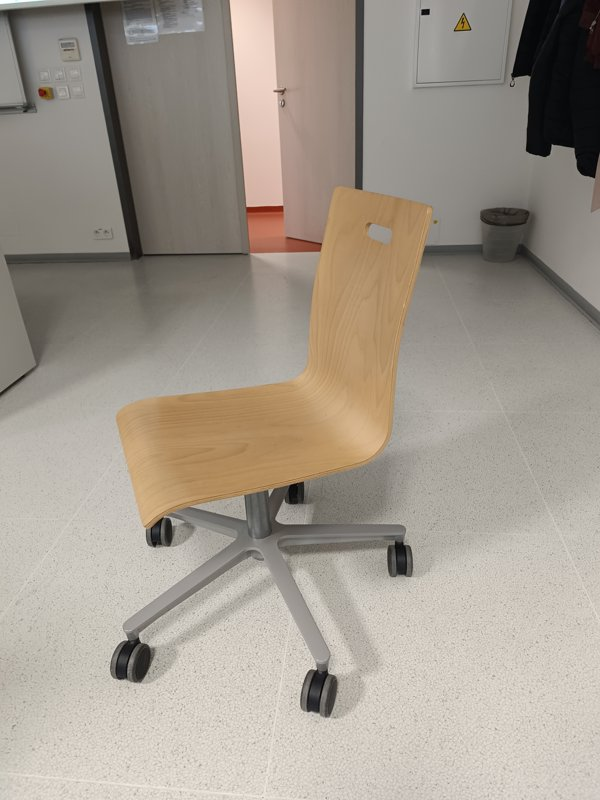

The input: one photograph of a real chair.

```
The photo reference.jpg shows a chair. Build a 3D model of it in Blender. Keep the curved wooden seat, the hole in the backrest and the base on five castors. Compare a render with the photo, adjust the proportions, and export the model to GLB. Make a page where I can rotate and zoom it.
```

**What to check:** turn the model sideways and compare the seat’s curve with the photo. The agent had to **guess** what the photo does not show. The Blender task of part 3 starts with a low-poly tree.

## Part 5 - the big task: BloodMNIST, a CNN and an Optuna study

**Goal: optimize the hyperparameters of a small convolutional neural network (CNN) in PyTorch using Optuna.** Train and compare configurations, choose the one with the best validation accuracy, then evaluate it **once** on the test split. The task is to carry out and document the hyperparameter search.

**Choose a reasonably small network that trains on a laptop CPU.** Agree on its size, the search ranges and the training budget with the agent before launching the study. The whole study should take about **15 minutes on CPU**; use the smoke test to check this budget and reduce the network or epochs if needed.

The data are [BloodMNIST](https://medmnist.com/): eight cell types, 28 × 28 RGB images, 17 092 images in the official split (11 959 training / 1 712 validation / 3 421 test). Download one file, [`bloodmnist.npz`](https://zenodo.org/records/10519652/files/bloodmnist.npz?download=1) (35 MB, MD5 `7053d0359d879ad8a5505303e11de1dc`, CC BY 4.0). Everything lives in `bloodmnist/`.

### Talk it through with the agent

No prepared prompt, no form. Say what you want and let it ask:

First save the five requirements below as `bloodmnist/REQUIREMENTS.md` - in a file the agent reads them every time; in the chat they are forgotten. Then:

```
In bloodmnist/, I want to optimize the hyperparameters of a small CNN on BloodMNIST with Optuna on the validation split. Choose a reasonably small network and search budget so the whole study runs on a laptop CPU in about 15 minutes; the test split is used once at the end. Read REQUIREMENTS.md first. Ask me whatever you need to know, write what we agree into PLAN.md, then start with a smoke test.
```

If it does not ask about something that matters (which split chooses, how long a trial may take, what is saved), say it. Then go in **small steps** - data, one configuration, a smoke test, the study, the test split last - and **commit after every step that works**.

**Work in parallel.** The full study runs for minutes. Do not watch it: open a **second terminal** in another folder and work on a small task, or ask for a subagent that reviews the code meanwhile.

### What the solution must contain

1. **Data.** `download_data.py` fetches the file, verifies the MD5 and keeps the official split; the standardization statistics (mean and std) come from the training split only.
2. **The search.** `tune.py` runs an Optuna study: objective = validation accuracy; at least three hyperparameters, at least one of them integer or categorical (number of channels, number of blocks, optimizer, …); at least eight trials; a pruner; a fixed seed; `trials.csv` with every trial, pruned ones included.
3. **The test split opened once.** `evaluate.py` evaluates the chosen configuration on the test split once and writes `test_metrics.json` (accuracy, balanced accuracy - the classes are not balanced) and `confusion_matrix.png`.
4. **Reproducible.** `pyproject.toml` and `uv.lock`, the exact commands in `bloodmnist/README.md`, seeds everywhere; a **smoke test** (two trials, one epoch) run twice gives the same `trials.csv` (so no timings in it - the wall-clock times go into `PLAN.md`).
5. **Report.** `report.html` with the learning curve of the chosen configuration, the trials table, the chosen configuration and the test metrics - every number equal to the one in the files - and one cautious sentence: what eight trials on one validation split can and cannot show, and that validation accuracy is not test accuracy.

`bloodmnist.npz` is **not** committed (`.gitignore`); `download_data.py` brings it back.

### The runtime budget and a slow laptop

The whole study must run on a laptop CPU in about **15 minutes** - a small network, few epochs, a pruner; done that way it takes a few minutes. If the smoke test takes more than two or three minutes, shrink the network or the epochs first. **On a slow laptop** run fewer epochs or trials, say exactly what and why in `PLAN.md`, and state the reduced budget in the report. A smaller study done honestly is a pass; a study never run is not.

### `REVIEW.md` is your own work

Three checks in `bloodmnist/REVIEW.md`, written by you, each with **the command you ran and what it printed** (or the file and line you read):

1. **The test split.** Search every script for it (`grep -n test *.py`, or *Find in files* in your editor) and quote the hits: loaded only in `evaluate.py`; mean and std from the training split.
2. **Reproducible.** Run the smoke test twice and compare the two `trials.csv` (`fc` on Windows, `cmp` on macOS/Linux) - identical?
3. **Three numbers.** The best validation accuracy and the test accuracy in `report.html` against `trials.csv` and `test_metrics.json`, and one more number of your choice.

Then a **fresh reviewer**: `/clear` and *“Start a subagent that reviews bloodmnist/ against REQUIREMENTS.md. It should find problems, not praise.”* (If the agent refuses to start one, ask the same in a new session.) Fix what it finds and note it in `REVIEW.md`.

## Part 6 - hand in

Compulsory hand-in: push **two tasks of your choice** and **the big task** to your private repository `aui-vibe-coding` shared with `MLRteacher` by **Friday 30 October 2026, 23:59**. What is pushed before the deadline counts. Hand-ins are checked with AI and for plagiarism. Attendance is not credited without it.

Before the last push, check yourself - not the agent - **in the browser** at `https://github.com/<your-login>/aui-vibe-coding`, because that is what will be opened:

1. **Private and shared:** the *Private* badge; *Settings → Collaborators* lists `MLRteacher`.
2. **Rules and state:** `AGENTS.md`, `CLAUDE.md` (`@AGENTS.md`), `README.md`, your full name in the top-level `README.md`, and `PLAN.md` with an entry per task (what you asked, the change, what you checked).
3. **Two task folders**, each with what its *Done when* lists.
4. **`bloodmnist/`** meeting the five requirements, with `README.md`, `report.html` and **your own `REVIEW.md`**; no `bloodmnist.npz`.
5. **No secrets:** searching the repository for `sk-` finds nothing; no `.claude`, no `.venv`.
6. **Everything pushed:** `git status` says `nothing to commit, working tree clean`; the last commit is before the deadline.

The agent may write the code and the report; the review and the responsibility are yours. Could you explain your result if the agent session disappeared? (AI use at BUT: check, understand, disclose - vut.cz/ai.)

## What you should take away

1. **Small prompts, and let it ask** - and write the answers into a file.
2. **Write everything into files** - `AGENTS.md`, `PLAN.md`, Markdown and HTML. The chat is forgotten.
3. **Subagents and parallel work** - a fresh helper for a review or a stuck problem; a second terminal while the first agent works.
4. **Check with something it cannot fake.** Commit before, look after.
5. **The validation split chooses, the test split is opened once** - and your review says where the code guarantees it.

[MLR lecture 5](https://tomasvicar.github.io/MLR-public/lectures/L5.html) and [MLR lab 5](https://tomasvicar.github.io/MLR-public/exercises/ex05.html) (the course MPA-MLR, Machine Learning and Recognition) go deeper.

## After the lab - back to a subscription, or uninstall

Step 3 pointed Claude Code at CERIT-SC through two files in your home folder. Two ways back, depending on what you want. **Close every Claude Code session first** (`/exit`) - Windows cannot delete a program that is running. Your project folders, their `AGENTS.md`, `CLAUDE.md` and Git history are not touched by either block.

**A - keep Claude Code, sign in with your own account.** This deletes only the two files of step 3 (the endpoint, the key, the model names and the skipped login screen); the next `claude` asks how to sign in again - a Claude subscription or an Anthropic Console API key - exactly as after a fresh installation, and the automatic updates are switched back on.

**Windows (PowerShell)**

```powershell
Remove-Item "$HOME\.claude\settings.json", "$HOME\.claude.json" -Force -ErrorAction SilentlyContinue
```

**macOS**

```bash
rm -f ~/.claude/settings.json ~/.claude.json
```

**Linux**

```bash
rm -f ~/.claude/settings.json ~/.claude.json
```

**Done when:** `claude` (in a project folder) shows the theme choice and then *Select login method*; `/status` no longer shows `llm.ai.e-infra.cz`.

**B - remove Claude Code completely.** This deletes the program, its downloaded versions, the settings with your key and the saved conversation histories (`.claude`).

**Windows (PowerShell)**

```powershell
& {
Remove-Item "$HOME\.local\bin\claude.exe" -Force -ErrorAction SilentlyContinue
Remove-Item "$HOME\.local\share\claude", "$HOME\.local\state\claude", "$HOME\.cache\claude", "$HOME\.claude", "$HOME\.claude.json" -Recurse -Force -ErrorAction SilentlyContinue

$claudeBin = Join-Path $env:USERPROFILE ".local\bin"
if (-not (Get-ChildItem $claudeBin -Force -ErrorAction SilentlyContinue)) {
  foreach ($scope in @("User", "Process")) {
    $currentPath = [string][Environment]::GetEnvironmentVariable("Path", $scope)
    $kept = @($currentPath -split ";" | Where-Object {
      $_.Trim() -and [Environment]::ExpandEnvironmentVariables($_.Trim()).TrimEnd("\") -ne $claudeBin.TrimEnd("\")
    })
    [Environment]::SetEnvironmentVariable("Path", ($kept -join ";"), $scope)
  }
}

if (Test-Path "$HOME\.local\bin\claude.exe") {
  Write-Host "claude.exe is still running - close every Claude window and run the block again."
} else {
  Write-Host "Claude Code is removed."
}
}
```

The block removes `.local\bin` from your `PATH` only when the folder is empty - `uv` from step 5 lives there too and keeps working.

**macOS**

```bash
rm -f ~/.local/bin/claude
rm -rf ~/.local/share/claude ~/.local/state/claude ~/.cache/claude ~/.claude ~/.claude.json
```

The `PATH` line of step 2 stays in `~/.zshrc`: `uv` from step 5 lives in the same folder. Delete the line by hand only if nothing else is in `~/.local/bin`.

**Linux**

```bash
rm -f ~/.local/bin/claude
rm -rf ~/.local/share/claude ~/.local/state/claude ~/.cache/claude ~/.claude ~/.claude.json
```

The `PATH` line of step 2 stays in `~/.bashrc`: `uv` from step 5 lives in the same folder. Delete the line by hand only if nothing else is in `~/.local/bin`.

**Done when:** in a **new** terminal `claude --version` says the command is not found.

**The key itself** still works after either block - it is stored at CERIT-SC, not only on your laptop. If you no longer need it, delete it at [chat.ai.e-infra.cz](https://chat.ai.e-infra.cz/) in *Settings → Account → API Keys*. A project folder may hold its own `.claude` folder with local permissions; delete it together with the project if you wish.